# Chapter 2 Regression and Model Validation

*This week I have worked on wrangling and analysing a dataset for learning approaches. I have learned how to do linear model analysis in R and produce visualizations of the results. For me, The trickiest part of this weeks exercise was understanding how to interpret the statistical tests and diagnostic plots and what they mean*

```r
date()
```

```
## [1] "Thu Nov 05 12:29:09 2020"
```

## 1

## 1.1 Reading the Dataset and Calling Packages

Packages required for this report include the dplyr, ggplot2, GGally and kableExtra packages. The packages are called with `library`.  
The dataset is in .csv format in the local directory and is read with the `read.csv` function and assigned a value (**l14**) below. For some reason the .csv is mutated with a column for row number. I leave it out by selecting the 7 variables with a `%>%` pipe operator.

```r
###library dplyr###

library(dplyr)
library(GGally)
```

```r
library(ggplot2)
library(kableExtra)
#read dataset from local directory

l14 <- read.csv("C:/Users/Jukke/OneDrive/Työpöytä/IODS/IODS-project/data/ln14_analysis.csv") %>% select(gender, Age, attitude, deep, stra, surf, Points)
```

## 1.2 Description of the Dataset

The **l14** dataset is derived from data collected by Vehkalahti (Dec 2014 - Jan 2015) ) from a questionnaire for Finnish students about their learning habits and approaches. The questionnaire includes a brief 32 item version of the ASSIST (Approaches and Study Skills Inventory for Students) as well as a SATS (Survey of Attitudes towards Statistics) ([link to meta documentation](https://www.mv.helsinki.fi/home/kvehkala/JYTmooc/JYTOPKYS3-meta.txt), accessed Nov 3rd 2020). Questions were answered on a scale of 1-5.  
The **l14** dataset consists of means counted for each respondent from clusters of questions related to the variables of attitude (10 items), deep learning (12 items), surface learning (12 items) and strategic learning (10 items) ([see here](https://www.mv.helsinki.fi/home/kvehkala/JYTmooc/JYTOPKYS2-meta.txt), accessed Nov 3 2020).  
Deep learning refers to student’s intention to maximize understanding. Surface learning refers to memorizing without understanding. Strategic learning refers to applying strategies that maximize possibilities for highest grades.

## 2

## 2.1 Graphical Overview

A graphical overview in Figure 1 displays the **l14** dataset and its 7 variables (gender, age, attitude, deep learning, strategic learning, surface learning and exam points) in relation to each other.  
The figure is produced with the `ggpairs` function from the GGally package.

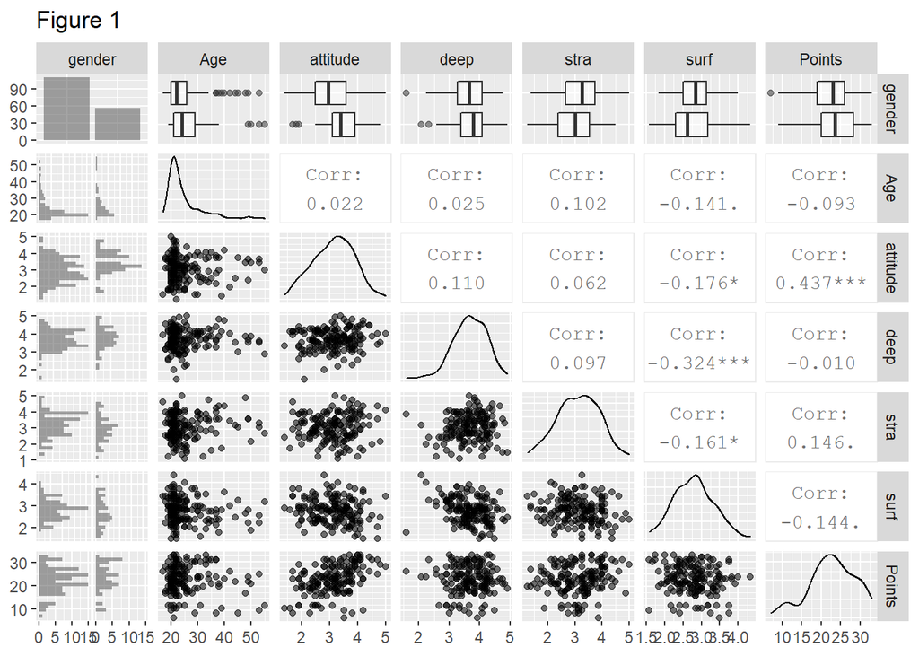

```r
p <- ggpairs(l14, mapping = aes(alpha = 0.3), lower = list(combo = wrap("facethist", bins = 20))) + ggtitle("Figure 1")

# draw the plot
p
```

From this overview we can find a correlation between attitude and exam points (0.437), as well as negative correlation between attitude and surface learning (memorizing without understanding) (-0.176) and a negative correlation between surface learning and deep learning (-0.324). These seem fairly intuitive as students might be expected to score systematically differently on deep and surface learning, and we might expect attitudes towards statistics to correlate with students’ exam points.

## 2.2 Variables

This section discusses the variables by exploring the dataset with the `summary` function and a `count` of gender. The summary shows the minimum and maximum values appearing in the dataset for each variable as well as their mean and median values.

```r
l14_sum <- summary(l14[-1])
print(l14_sum)
```

```
##       Age           attitude          deep            stra
##  Min.   :17.00   Min.   :1.400   Min.   :1.583   Min.   :1.250
##  1st Qu.:21.00   1st Qu.:2.600   1st Qu.:3.333   1st Qu.:2.625
##  Median :22.00   Median :3.200   Median :3.667   Median :3.188
##  Mean   :25.51   Mean   :3.143   Mean   :3.680   Mean   :3.121
##  3rd Qu.:27.00   3rd Qu.:3.700   3rd Qu.:4.083   3rd Qu.:3.625
##  Max.   :55.00   Max.   :5.000   Max.   :4.917   Max.   :5.000
##       surf           Points
##  Min.   :1.583   Min.   : 7.00
##  1st Qu.:2.417   1st Qu.:19.00
##  Median :2.833   Median :23.00
##  Mean   :2.787   Mean   :22.72
##  3rd Qu.:3.167   3rd Qu.:27.75
##  Max.   :4.333   Max.   :33.00
```

```r
l14_gen <- count(l14, gender)

kable(l14_gen, format = "html", caption = " Table 1 Students' Gender")
```

Table 1 Students’ Gender

| gender | n |
| --- | --- |
| F | 110 |
| M | 56 |

**Age**: Respondents are aged between 17 and 55 with the median age being 22.  
**Gender**: Male/Female with 56M and 110F  
**Learning approaches**: Deep, surface and strategic learning approaches and their min-max values occurring in the dataset (scored by means discussed in previous section)  
**Attitude**: Students’ attitude score and min-max values occurring in the dataset  
**Points**: Exam points with a range of 7-33 and a mean of 22.72

## 3

## 3.1 Selecting Explanatory Variables

This section will investigate the relation between the students’ exam points (target value) and their deep and surface learning approaches as well as their attitude. The objective is to find out if the explanatory variables (**attitude**, **surface learning**, **deep learning**) are associated in a systematic way to students’ exam points. First, lets look at the explanatory variables in relation to exam points individually in scatter plots:

### 3.1.1 Attitude and Exam Points

These scatter plots are produced with `ggplot2` by mapping the exploratory variables on the x axis with exam points on the y axis, and separated by gender with the `col = gender` value. The `geom_point` creates points for each location in the dataset. The `geom_smooth(method = "lm")` creates the linear regression model line. In section 3.2 these relations are explored further with multiple linear regression.

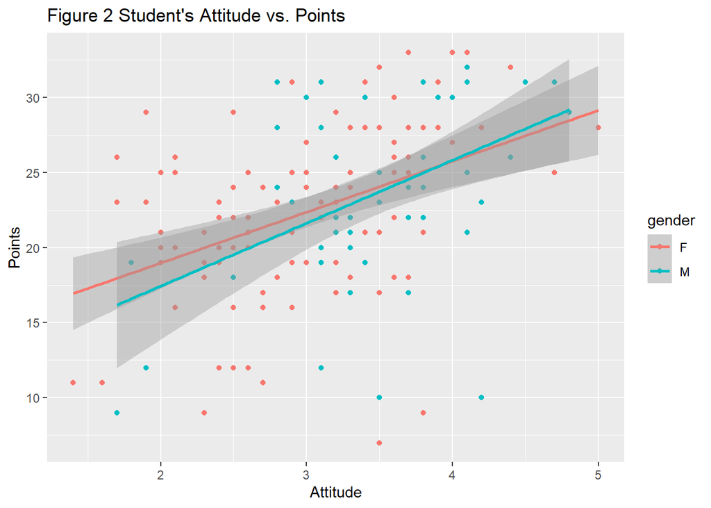

```r
plot_ap <- ggplot(l14, aes(x = attitude, y = Points, col = gender)) + geom_point() + geom_smooth(method = "lm") + ggtitle("Figure 2 Student's Attitude vs. Points") + labs(x = "Attitude")
plot_ap
```

Figure 2 shows that Attitude and Exam points seem to have some linear regression. The same can not be said for the deep learning and surface learning approaches (Figures 3 and 4) which do not show evidence towards significant linear regression:

### 3.1.2 Deep Learning and Exam Points

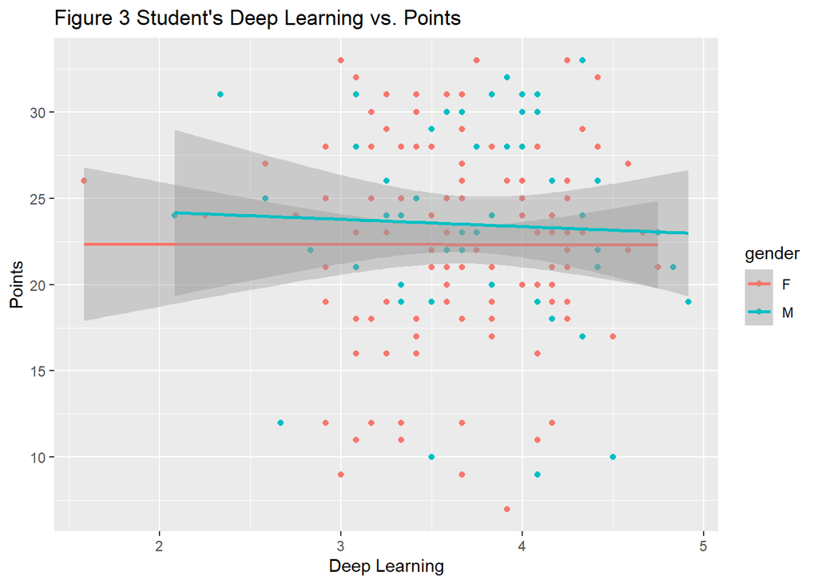

```r
plot_dp <- ggplot(l14, aes(x = deep, y = Points, col = gender)) + geom_point() + geom_smooth(method = "lm") + ggtitle("Figure 3 Student's Deep Learning vs. Points") + labs(x = "Deep Learning")
plot_dp
```

### 3.1.3 Surface Learning and Exam Points

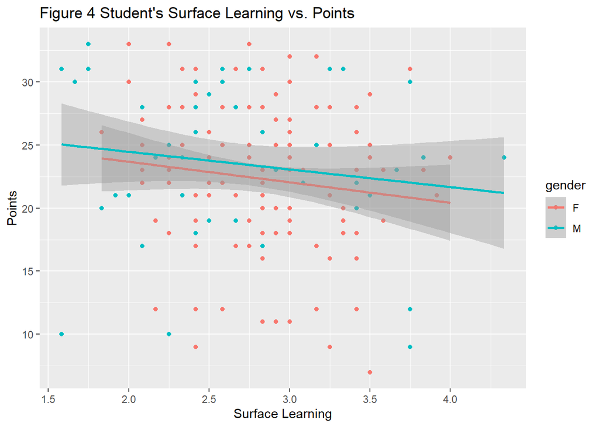

```r
plot_sp <- ggplot(l14, aes(x = surf, y = Points, col = gender)) + geom_point() + geom_smooth(method = "lm") + ggtitle("Figure 4 Student's Surface Learning vs. Points") + labs(x = "Surface Learning")
plot_sp
```

## 3.2 Multiple Regression

### 3.2.1 Overview of Variables

First, a quick graphic overview of the target variable (exam points) and explanatory variables (deep, surface, attitude) in a similar plot as in section 2. From this we can already deduce it may not make sense to perform a multiple regression analysis on the 3 variables because the surf and deep categories do not create a line of regression similar to attitude and points.  
A new dataset is created from the **l14** dataset selecting only the gender, attitude, surf, deep, and points variables. The dataset is plotted with the `plot` function and the first column (gender) omitted from the plot with `[-1]`.

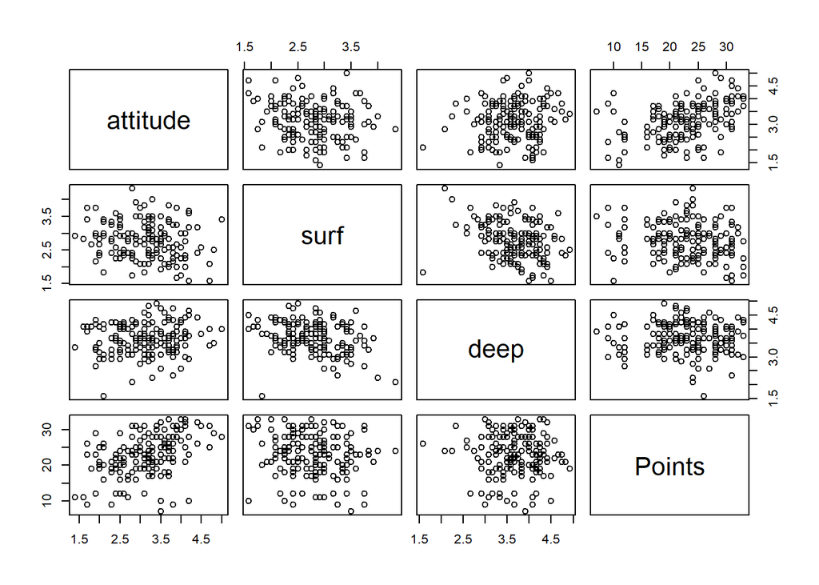

```r
l14_b <- select(l14, gender, attitude, surf, deep, Points)

plot(l14_b[-1])
```

### 3.2.2 Multiple Regression Model

For multiple regression, a formula is created with the `lm` linear model function that is assigned with the target value (Points) and the explanatory values (attitude + deep + surf). This means that points is predicted by attitude, deep learning, and surface learning. The formula is assigned as multiple_regression and a `summary` function produces the information below:

```r
multiple_regression <- lm(Points ~ attitude + deep + surf, data = l14)
mr <- summary(multiple_regression)
print(mr)
```

```
##
## Call:
## lm(formula = Points ~ attitude + deep + surf, data = l14)
##
## Residuals:
##      Min       1Q   Median       3Q      Max
## -16.9168  -3.1487   0.3667   3.8326  11.3519
##
## Coefficients:
##             Estimate Std. Error t value Pr(>|t|)
## (Intercept)  18.3551     4.7124   3.895 0.000143 ***
## attitude      3.4661     0.5766   6.011 1.18e-08 ***
## deep         -0.9485     0.7903  -1.200 0.231815
## surf         -1.0911     0.8360  -1.305 0.193669
## ---
## Signif. codes:  0 '***' 0.001 '**' 0.01 '*' 0.05 '.' 0.1 ' ' 1
##
## Residual standard error: 5.313 on 162 degrees of freedom
## Multiple R-squared:  0.2024, Adjusted R-squared:  0.1876
## F-statistic:  13.7 on 3 and 162 DF,  p-value: 5.217e-08
```

The multiple regression summary provides results for the validity of the model. The model’s adjusted R-Squared value is 0.1876, this is a fairly low score meaning that the three explanatory variables together account for only 19% of the variation.

The F-test for testing the hypothesis that all three regression coefficients are zero has a very low associated p-value. Thus there is strong evidence that not all three coefficients are zero.  
The Pr(>|t|) values for attitude, deep, and surf indicate that a) using attitude and deep would be better at predicting exam points and b) using attitude and surf would be better at predicting exam points. By changing the model to these two variants we can examine the validity of new models attitude + deep and attitude + surf:

```r
multiple_regression_ad <- lm(Points ~ attitude + deep, data = l14)
mrad <- summary(multiple_regression_ad)
multiple_regression_as <- lm(Points ~ attitude + surf, data = l14)
mras <- summary(multiple_regression_as)

print(mrad)
```

```
##
## Call:
## lm(formula = Points ~ attitude + deep, data = l14)
##
## Residuals:
##      Min       1Q   Median       3Q      Max
## -16.8463  -3.2975   0.2789   4.1213  11.1399
##
## Coefficients:
##             Estimate Std. Error t value Pr(>|t|)
## (Intercept)  13.7812     3.1574   4.365 2.25e-05 ***
## attitude      3.5780     0.5714   6.262 3.25e-09 ***
## deep         -0.6275     0.7526  -0.834    0.406
## ---
## Signif. codes:  0 '***' 0.001 '**' 0.01 '*' 0.05 '.' 0.1 ' ' 1
##
## Residual standard error: 5.325 on 163 degrees of freedom
## Multiple R-squared:  0.194,  Adjusted R-squared:  0.1841
## F-statistic: 19.62 on 2 and 163 DF,  p-value: 2.326e-08
```

For the model with attitude and deep learning the result is similar, attitude alone would be a better model.

```r
print(mras)
```

```
##
## Call:
## lm(formula = Points ~ attitude + surf, data = l14)
##
## Residuals:
##     Min      1Q  Median      3Q     Max
## -17.277  -3.236   0.386   3.977  10.642
##
## Coefficients:
##             Estimate Std. Error t value Pr(>|t|)
## (Intercept)  14.1196     3.1271   4.515 1.21e-05 ***
## attitude      3.4264     0.5764   5.944 1.63e-08 ***
## surf         -0.7790     0.7956  -0.979    0.329
## ---
## Signif. codes:  0 '***' 0.001 '**' 0.01 '*' 0.05 '.' 0.1 ' ' 1
##
## Residual standard error: 5.32 on 163 degrees of freedom
## Multiple R-squared:  0.1953, Adjusted R-squared:  0.1854
## F-statistic: 19.78 on 2 and 163 DF,  p-value: 2.041e-08
```

In the next section, the linear regression of exam points and attitude is examined by removing the deep and surface learning variables.

## 3.3 Model Changed to Simple Linear Regression

A similar formula is created as in the previous section. This time the formula is simple with points and attitude as the only values.

```r
regression <- lm(Points ~ attitude, data = l14)
summary(regression)
```

```
##
## Call:
## lm(formula = Points ~ attitude, data = l14)
##
## Residuals:
##      Min       1Q   Median       3Q      Max
## -16.9763  -3.2119   0.4339   4.1534  10.6645
##
## Coefficients:
##             Estimate Std. Error t value Pr(>|t|)
## (Intercept)  11.6372     1.8303   6.358 1.95e-09 ***
## attitude      3.5255     0.5674   6.214 4.12e-09 ***
## ---
## Signif. codes:  0 '***' 0.001 '**' 0.01 '*' 0.05 '.' 0.1 ' ' 1
##
## Residual standard error: 5.32 on 164 degrees of freedom
## Multiple R-squared:  0.1906, Adjusted R-squared:  0.1856
## F-statistic: 38.61 on 1 and 164 DF,  p-value: 4.119e-09
```

## 3.4 Diagnostic Plots

Diagnostic plots can be used to examine the violations in linear regression assumptions. Diagnostics plot can be made with `plot` function by assignin the linear model formula, created in section 3.3 as the data. The `which = c()` value selects the desired plots, in this case: Residuals vs Fitted, Normal Q-Q, and Residuals vs Leverage plots.

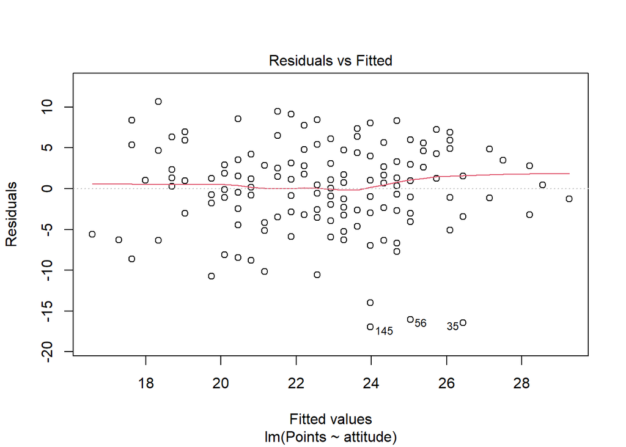

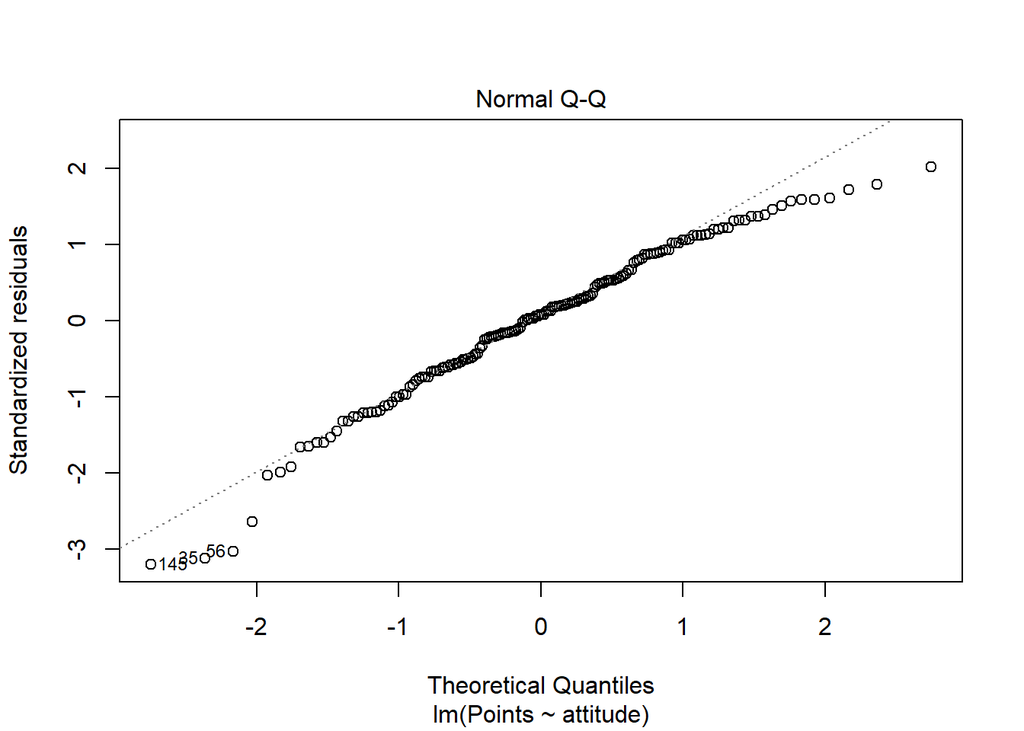

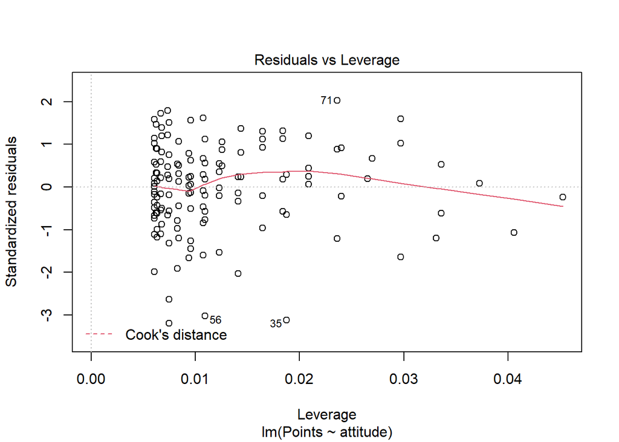

```r
dp <- plot(regression, which = c(1,2,5))
```

### 3.4.1 Residuals vs Fitted

The Residuals vs Fitted plot shows whether linearity holds. In addition, the spread of residuals should stay the same on the x-axis. In this plot the linearity holds reasonably well. There are however some outliers (145, 56, 35) that challenge assumptions of linearity.

### 3.4.2 Normal Q-Q

The Normal Q-Q plot provides a method to explore the normality assumption that errors are normally distributed. The Normal Q-Q plot shows that there is a reasonable fit in middle of the line but questionable in the beginning.

### 3.4.3 Residuals vs Leverage

Leverage measures a single observations impact on the model. Observations with unusually high impact can be found with the Residuals vs Leverage plot.

## 4 Conclusion

It always helps to have a positive attitude!